# 1. Preliminary Research

In this first section we will briefly introduce **Variational Autoencoders (VAEs)** and **Generative Adversarial Networks (GANs)**, along with its main variations, two of the most widely used deep learning methods for image generation.

## 1.1 Variational Autoencoders (VAEs)

### Introduction

To lay the groundwork for understanding Variational Autoencoders (VAEs), it's crucial to grasp the concept of Autoencoders (AEs) first. AEs are neural networks adept at compressing and decompressing data, akin to VAEs. However, unlike VAEs, AEs do not explicitly model the underlying probability distribution of the data, posing a challenge in generating new samples from the learned latent space. AEs are trained to minimize the reconstruction error between input and output data, serving purposes like data compression, denoising, and anomaly detection.

### Architecture

VAEs are generative models rooted in neural networks, aimed at encoding high-dimensional data into a lower-dimensional latent space and reconstructing it into the original data space. The VAE architecture, akin to an AE, comprises three primary components: a coding network for compressing data by mapping it to a latent distribution, a bottleneck housing the compressed information, and a decoding network for translating latent variables back into the data space.

However, while AEs focus on minimizing reconstruction error, they lack a mechanism to organize the latent space. Consequently, in AEs, decoding meaningful content from a random point in the latent space isn't guaranteed. To address this limitation, VAEs introduce structure to the latent space to enhance generative capabilities.

Rather than encoding inputs as single points, VAEs encode them as probability distributions across the latent space (typically multivariate Gaussian distributions). Subsequently, a point is sampled from this distribution for decoding, with the reconstruction error computed and propagated back through the network. Additionally, KL divergences serve as a regularization term to ensure the distribution approximates a Normal(0,1).

Moreover, due to the sampling involved in the backpropagation process, direct backpropagation isn't feasible. Thus, the reparametrization trick introduces a hidden state, enabling the process and ensuring continuity. This trick not only facilitates error propagation but also maintains consistency, as similar distributions in the latent space regenerate similar contents. Importantly, it imbues random points with meaningful representations, a significant advantage over simple AEs.

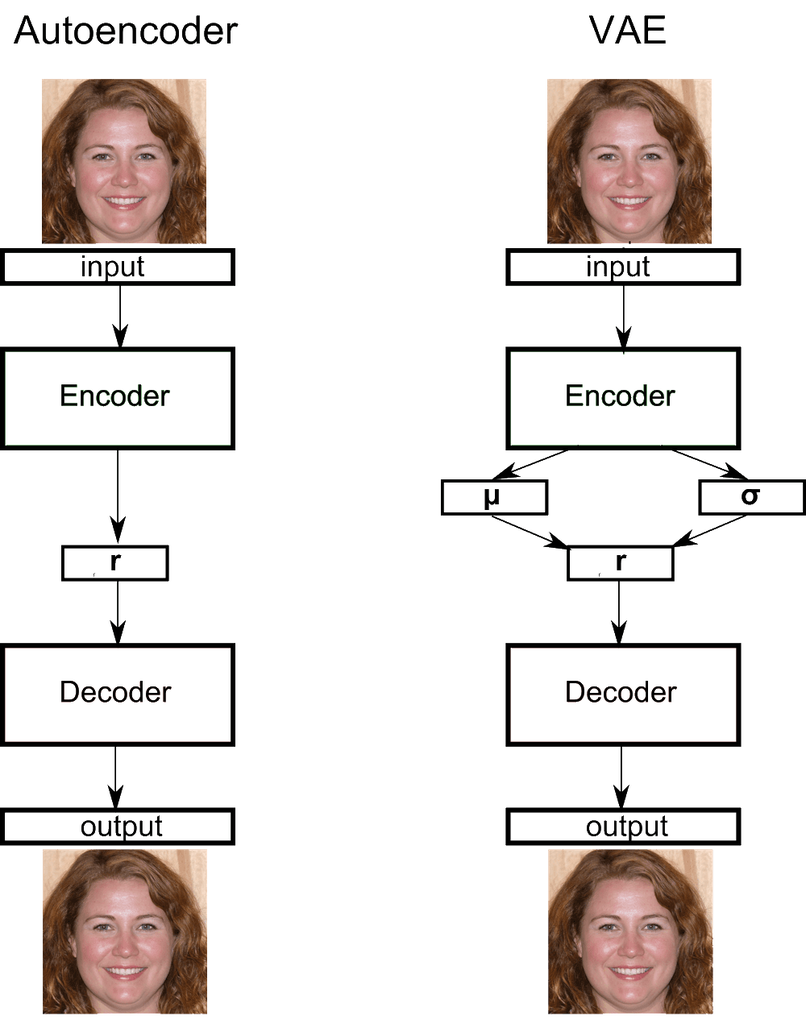

### Application

VAEs are extensively utilized in various generative tasks. Despite being primarily designed for generative purposes, they are also employed in tasks like data compression and anomaly detection. In essence, the VAE model stands as a potent tool for generating new data akin to the input data. Its generative capabilities span diverse fields such as image generation, audio synthesis, text generation, and product design, facilitating exploration and creation of novel instances based on the learned distribution from the original dataset.

## 1.2 Generative Adversarial Networks (GANs)

### Introduction

GANs, or Generative Adversarial Networks, represent another category of generative models featuring two neural networks: a generator and a discriminator. The generator network maps random noise vectors to fake data samples, while the discriminator network learns to differentiate between real and fake samples produced by the generator. These networks are trained concurrently in a minimax game, where the generator aims to deceive the discriminator, while the discriminator strives to accurately classify samples as real or fake.

Consequently, the overall loss function of GANs comprises two components: the generator loss and the discriminator loss. The generator loss quantifies the disparity between generated and real data samples, whereas the discriminator loss assesses the discriminator's ability to discern between real and fake samples. These losses are iteratively optimized during training to enhance the quality of generated samples.

Regarding the learning process, emphasis is placed on backpropagating the discriminator's error to the generator. However, training the generator becomes complex if the discriminator's improvement occurs simultaneously. Consequently, the training of both components of the architecture isn't simultaneous; typically, in each epoch, the discriminator is trained first, followed by the generator. This approach risks conflating the discriminator's weights during generator learning.

Unlike VAEs, achieving convergence in GANs poses greater challenges due to the need to learn the distribution via the discriminator and a minmax optimization process. To attain satisfactory results, neither the discriminator nor the generator should dominate the other.

When the generator surpasses the discriminator, poor outcomes ensue due to "collapse mode," where the generator deceives the discriminator with nearly identical images. Conversely, if the discriminator excels, it fails to provide informative gradients, leading to vanishing gradients. To mitigate the latter, two approaches are commonly employed: modifying the minimax loss, as proposed in the original GANs paper, or utilizing Wasserstein loss. The Wasserstein loss not only circumvents vanishing gradients, even when the discriminator is optimally trained, but also furnishes a meaningful error value by measuring the disparity between real and generated sample probability distributions.

It's worth noting that various GAN variations, including those incorporating the Wasserstein loss term, will be discussed subsequently.

[figure not shown]

### Deep Convolutional GANs (DCGANs)

DCGANs represent a variation of GANs employing convolutional neural networks (CNNs) for both the generator and discriminator networks. Leveraging convolutions, DCGANs have demonstrated the capability to produce high-quality images, establishing their prominence in image generation tasks.

### Wasserstein GAN with Gradient Penalty (WGAN-GP)

WGAN-GP stands as a variant of GANs employing the Wasserstein distance metric to quantify the discrepancy between real and fake data distributions. In WGAN-GP, a gradient penalty term supplements the loss function, imposing the Lipschitz constraint on the discriminator network (referred to as the critic in this context, as it doesn't handle probabilities). This constraint enhances training stability and elevates the quality of generated samples. Notably, the gradient penalty is exclusive to the discriminator, while the generator solely utilizes the Wasserstein loss.

Distinguishing features from DCGANs include:

- DCGANs update both the discriminator and generator concurrently, whereas WGAN-GPs perform multiple discriminator updates for every generator update to ensure training equilibrium.
- While DCGANs employ a sigmoid function to output probabilities, WGAN-GPs directly compute the Wasserstein loss.
- DCGANs incorporate noise in labels to bolster training stability, akin to data augmentation techniques.

## Application

Generative Adversarial Networks (GANs) encompass a broad spectrum of applications across various domains, including image and video generation, data augmentation, and style transfer. In image and video generation, GANs excel in producing realistic, high-fidelity samples. They are also instrumental in data augmentation, where the generator network synthesizes artificial data samples to augment the training dataset size, thereby enhancing model generalization performance. Furthermore, GANs have been leveraged for style transfer tasks, wherein the generative network learns to transpose the style from one image onto another while preserving the original image's content.

Overall, GANs represent a robust generative model capable of addressing a myriad of tasks, including those exemplified for VAEs, and have demonstrated promising outcomes across diverse applications.

## Generative Adversarial Networks (GANs) vs. Variational Autoencoders (VAEs)

In recent years, GANs have garnered considerable attention owing to their adeptness in generating high-quality samples that surpass VAEs. GANs achieve this by implicitly learning the data distribution, whereas VAEs explicitly model it. Moreover, GANs exhibit superior performance in generating high-resolution images and modeling complex data distributions.

Nevertheless, VAEs possess certain advantages over GANs. They are more stable during training and are not prone to **mode collapse**, a phenomenon wherein the generator produces a limited set of samples, failing to capture the diversity of the data distribution. Additionally, VAEs offer a clear probabilistic interpretation, which proves beneficial for tasks like anomaly detection and data compression.

To summarize, both VAEs and GANs boast distinct strengths and weaknesses, while operating at a similar structural level in generating outputs. The selection between the two models hinges on the specific requirements of the task at hand.

[figure not shown]